# BCG_DS_Forage_Simulation_PowerCo_EDA

PowerCo Churn Analysis: Exploratory Data Analysis of Client and Price Data

The aim here is to analyze the client_data.csv and price_data.csv from PowerCo to indicate wheather the price sensitivity is a strong indicator of customer churn or not. In this notebook, we are performing Exploratory Data Analysis(EDA) on these datasets, data cleaning, data preprocessing and indentifying important trends for futher use using descriptive statistics.

In the 1st step, we start by import all the necessary libraries including data visualization libraries for our EDA. Then we import our datasets here and see if the data was properly loaded or not.

```python
# Importing all necessary libraries
import pandas as pd
import numpy as np
import matplotlib.pyplot as plt
import seaborn as sns
import plotly as pl
```

```python
# Fetching the files from gdrive
from google.colab import drive

# Mount Google Drive
print("Mounting Google Drive...")
drive.mount('/content/drive')

file_path1 = '/content/drive/MyDrive/BCG DS Forage simulation/BCG-Forage_PowerCo_Price Data.csv'
df_price = pd.read_csv(file_path1)

file_path2 = '/content/drive/MyDrive/BCG DS Forage simulation/BCG-Forage_PowerCo_Client Data.csv'
df_client = pd.read_csv(file_path2)
```

```
Mounting Google Drive...
```

```python
# Display the first few rows to verify
print("--- (Client Data) ---")
print(df_client.head())
```

```
--- (Client Data) ---
                                 id                     channel_sales  \
0  24011ae4ebbe3035111d65fa7c15bc57  foosdfpfkusacimwkcsosbicdxkicaua
1  d29c2c54acc38ff3c0614d0a653813dd                           MISSING
2  764c75f661154dac3a6c254cd082ea7d  foosdfpfkusacimwkcsosbicdxkicaua
3  bba03439a292a1e166f80264c16191cb  lmkebamcaaclubfxadlmueccxoimlema
4  149d57cf92fc41cf94415803a877cb4b                           MISSING

   cons_12m  cons_gas_12m  cons_last_month  date_activ    date_end  \
0         0         54946                0  2013-06-15  2016-06-15
1      4660             0                0  2009-08-21  2016-08-30
2       544             0                0  2010-04-16  2016-04-16
3      1584             0                0  2010-03-30  2016-03-30
4      4425             0              526  2010-01-13  2016-03-07

```

[output cut: 22 more lines]

```python
# Display first few rows to verify
print("\n--- (Pricing Data) ---")
print(df_price.head())
```

```
--- (Pricing Data) ---
                                 id  price_date  price_off_peak_var  \
0  038af19179925da21a25619c5a24b745  2015-01-01            0.151367
1  038af19179925da21a25619c5a24b745  2015-02-01            0.151367
2  038af19179925da21a25619c5a24b745  2015-03-01            0.151367
3  038af19179925da21a25619c5a24b745  2015-04-01            0.149626
4  038af19179925da21a25619c5a24b745  2015-05-01            0.149626

   price_peak_var  price_mid_peak_var  price_off_peak_fix  price_peak_fix  \
0             0.0                 0.0           44.266931             0.0
1             0.0                 0.0           44.266931             0.0
2             0.0                 0.0           44.266931             0.0
3             0.0                 0.0           44.266931             0.0
4             0.0                 0.0           44.266931             0.0

   price_mid_peak_fix
0                 0.0
1                 0.0
2                 0.0
3                 0.0
4                 0.0
```

Here, we analyze the data types and any missing or null values in our two datasets and identify important target columns and if we need to convert any other columns, for example we need to convert some columns from both datasets to datetime type for time-series forecasting.

```python
# Data Types and Missing Values (df_client)
print("\n df_client: Data Types and Missing Values")
# Use .info() to display dtypes and non-null counts simultaneously
df_client.info()

print("\n df_client: Unique Values Analysis")
# Check how many different values are in each column to see if it's a unique ID, a measurement (high count), or a category (low count).
# High Count (e.g., > 10,000):
# This represents a **continuous numerical measurement** (like consumption or revenue)
# or a **unique identifier**. It means most clients have their own distinct value.
# These columns are prone to **skewness and outliers**, which must be checked in visualization.

# Low Count (e.g., < 50):
# This represents a **categorical feature** (like a sales channel, contract type, or a Yes/No field).
# It means clients are grouped into a small number of buckets. These features are great for
# plotting frequencies and are usually processed via one-hot encoding for modeling.
print(df_client.nunique().sort_values(ascending=False))
print("-" * 70)
```

```
 df_client: Data Types and Missing Values
<class 'pandas.core.frame.DataFrame'>
RangeIndex: 14606 entries, 0 to 14605
Data columns (total 26 columns):
 #   Column                          Non-Null Count  Dtype
---  ------                          --------------  -----
 0   id                              14606 non-null  object
 1   channel_sales                   14606 non-null  object
 2   cons_12m                        14606 non-null  int64
 3   cons_gas_12m                    14606 non-null  int64
 4   cons_last_month                 14606 non-null  int64
 5   date_activ                      14606 non-null  object
 6   date_end                        14606 non-null  object
 7   date_modif_prod                 14606 non-null  object
 8   date_renewal                    14606 non-null  object
 9   forecast_cons_12m               14606 non-null  float64
 10  forecast_cons_year              14606 non-null  int64
 11  forecast_discount_energy        14606 non-null  float64
 12  forecast_meter_rent_12m         14606 non-null  float64
 13  forecast_price_energy_off_peak  14606 non-null  float64
 14  forecast_price_energy_peak      14606 non-null  float64
 15  forecast_price_pow_off_peak     14606 non-null  float64
 16  has_gas                         14606 non-null  object
 17  imp_cons                        14606 non-null  float64
 18  margin_gross_pow_ele            14606 non-null  float64
 19  margin_net_pow_ele              14606 non-null  float64
 20  nb_prod_act                     14606 non-null  int64
 21  net_margin                      14606 non-null  float64
 22  num_years_antig                 14606 non-null  int64
 23  origin_up                       14606 non-null  object
 24  pow_max                         14606 non-null  float64
 25  churn                           14606 non-null  int64
dtypes: float64(11), int64(7), object(8)
memory usage: 2.9+ MB

 df_client: Unique Values Analysis
id                                14606
forecast_cons_12m                 13993
net_margin                        11965
cons_12m                          11065
```

[output cut: 9 more lines]

```
pow_max                             698
forecast_price_energy_off_peak      516
date_renewal                        386
date_end                            368
forecast_price_energy_peak          329
forecast_price_pow_off_peak          41
num_years_antig                      13
forecast_discount_energy             12
nb_prod_act                          10
channel_sales                         8
origin_up                             6
has_gas                               2
churn                                 2
dtype: int64
----------------------------------------------------------------------
```

```python
print("\n df_price: Data Types and Missing Values")
# Use .info() to display dtypes and non-null counts simultaneously
df_price.info()

print("\n df_price: Unique Values Analysis")

print(df_price.nunique().sort_values(ascending=False))
print("-" * 70)
```

```
 df_price: Data Types and Missing Values
<class 'pandas.core.frame.DataFrame'>
RangeIndex: 193002 entries, 0 to 193001
Data columns (total 8 columns):
 #   Column              Non-Null Count   Dtype
---  ------              --------------   -----
 0   id                  193002 non-null  object
 1   price_date          193002 non-null  object
 2   price_off_peak_var  193002 non-null  float64
 3   price_peak_var      193002 non-null  float64
 4   price_mid_peak_var  193002 non-null  float64
 5   price_off_peak_fix  193002 non-null  float64
 6   price_peak_fix      193002 non-null  float64
 7   price_mid_peak_fix  193002 non-null  float64
dtypes: float64(6), object(2)
memory usage: 11.8+ MB

 df_price: Unique Values Analysis
id                    16096
price_off_peak_var     1853
price_peak_var         1189
price_mid_peak_var      711
price_off_peak_fix       66
price_peak_fix           31
price_mid_peak_fix       28
price_date               12
dtype: int64
----------------------------------------------------------------------
```

Here, in the below step we identified necessary columns from both datasets to convert them to datetime format for time based EDA.

```python
# Date Conversion (Mandatory for Time-Based EDA)
print("Converting Date Columns to datetime")

# Columns to convert in df_client
date_cols_client = ['date_activ', 'date_end', 'date_modif_prod', 'date_renewal']
for col in date_cols_client:
    df_client[col] = pd.to_datetime(df_client[col], errors='coerce')

# Column to convert in df_price
df_price['price_date'] = pd.to_datetime(df_price['price_date'], errors='coerce')

print("\n Client data in date time format:")
print(df_client[date_cols_client].dtypes)

# Column to convert in df_price
df_price['price_date'] = pd.to_datetime(df_price['price_date'], errors='coerce')
print("\n Price data in date time format:")
print(df_price[['price_date']].dtypes)
```

```
Converting Date Columns to datetime

 Client data in date time format:
date_activ         datetime64[ns]
date_end           datetime64[ns]
date_modif_prod    datetime64[ns]
date_renewal       datetime64[ns]
dtype: object

 Price data in date time format:
price_date    datetime64[ns]
dtype: object
```

Following code block provides a numerical summary of both customer data (df_client) and price data (df_price) to quickly identify problems like extreme values and imbalance.

1. Client Numeric Statistics (df_client.describe()):
- What it does: Calculates the mean, max, and percentiles for every numerical column (like consumption and margin).
- The Goal: To immediately spot if a few extremely large customers (outliers) are making the average number misleading.
2. Churn Rate Calculation (.value_counts()):
- What it does: Calculates the exact percentage of customers leaving versus those staying (your churn rate).
- The Goal: To confirm and quantify the class imbalance problem you must solve for modeling.
3. Price Statistics (df_price.describe()):
- What it does: Calculates the mean, max, and standard deviation for the historical price components.
- The Goal: To determine if energy prices have been stable or volatile over time, which is key context for analyzing customer price sensitivity.

```python
# Client data: Numeric Statistics and Churn Imbalance
print("\nClient data: Numeric Statistics (Consumption, Financials, Tenure)")
# Summary statistics will show outliers (Max vs. 75%) and skewness (Mean vs. Median)
print(df_client.describe(include=np.number)) ## This quickly shows the average, the spread, and if there are any extreme high or low outliers in the customer metrics.

print("-" * 70)
print("\ndf_client: Churn Rate (Target Variable Balance)")
# Quantify the class imbalance
churn_counts = df_client['churn'].value_counts(normalize=True) * 100 ## This tells what percentage of the total customers are leaving the company (the 1s) versus those who are staying (the 0s). This result is crucial because it confirms the class imbalance problem.
print(churn_counts)
print(f"\nConclusion: The overall churn rate is {churn_counts[1]:.2f}%, confirming a significant **class imbalance** (this is a key finding!).")
print("-" * 70)

# Price data: Statistics
print("\nPrice data: Price Component Statistics")
# Summary of the fixed and variable price components
print(df_price.describe(include=np.number))
print("-" * 70)
```

```
Client data: Numeric Statistics (Consumption, Financials, Tenure)
           cons_12m  cons_gas_12m  cons_last_month  forecast_cons_12m  \
count  1.460600e+04  1.460600e+04     14606.000000       14606.000000
mean   1.592203e+05  2.809238e+04     16090.269752        1868.614880
std    5.734653e+05  1.629731e+05     64364.196422        2387.571531
min    0.000000e+00  0.000000e+00         0.000000           0.000000
25%    5.674750e+03  0.000000e+00         0.000000         494.995000
50%    1.411550e+04  0.000000e+00       792.500000        1112.875000
75%    4.076375e+04  0.000000e+00      3383.000000        2401.790000
max    6.207104e+06  4.154590e+06    771203.000000       82902.830000

       forecast_cons_year  forecast_discount_energy  forecast_meter_rent_12m  \
count        14606.000000              14606.000000             14606.000000
mean          1399.762906                  0.966726                63.086871
std           3247.786255                  5.108289                66.165783
min              0.000000                  0.000000                 0.000000
25%              0.000000                  0.000000                16.180000
50%            314.000000                  0.000000                18.795000
75%           1745.750000                  0.000000               131.030000
max         175375.000000                 30.000000               599.310000

       forecast_price_energy_off_peak  forecast_price_energy_peak  \
count                    14606.000000                14606.000000
mean                         0.137283                    0.050491
std                          0.024623                    0.049037
min                          0.000000                    0.000000
25%                          0.116340                    0.000000
50%                          0.143166                    0.084138
75%                          0.146348                    0.098837
max                          0.273963                    0.195975

       forecast_price_pow_off_peak      imp_cons  margin_gross_pow_ele  \
count                 14606.000000  14606.000000          14606.000000
mean                     43.130056    152.786896             24.565121
std                       4.485988    341.369366             20.231172
min                       0.000000      0.000000              0.000000
25%                      40.606701      0.000000             14.280000
50%                      44.311378     37.395000             21.640000
75%                      44.311378    193.980000             29.880000
max                      59.266378  15042.790000            374.640000
```

[output cut: 37 more lines]

```
25%              0.125976        0.000000            0.000000
50%              0.146033        0.085483            0.000000
75%              0.151635        0.101673            0.072558
max              0.280700        0.229788            0.114102

       price_off_peak_fix  price_peak_fix  price_mid_peak_fix
count       193002.000000   193002.000000       193002.000000
mean            43.334477       10.622875            6.409984
std              5.410297       12.841895            7.773592
min              0.000000        0.000000            0.000000
25%             40.728885        0.000000            0.000000
50%             44.266930        0.000000            0.000000
75%             44.444710       24.339581           16.226389
max             59.444710       36.490692           17.458221
----------------------------------------------------------------------
```

Here, we start with our data visualization for both the datasets. We perform the Categorical Data Visualization step of our EDA.

It creates three separate bar charts (count plots) side-by-side to visually show the breakdown and frequency of the key customer groups.

- Overview of Code Actions:

Chart 1: Churn Distribution:

- What it shows: The total count of customers who are staying (0) versus the few who are leaving (1).
- The Goal: To visually confirm the severe 9.7% imbalance we found in the statistics.

Chart 2: Gas Client Status (has_gas):

- What it shows: The count of customers who are dual-fuel (have gas and electricity) versus those who are electricity-only.
- The Goal: To understand the size of the different customer segments.

Chart 3: Top Sales Channels:

- What it shows: The count of customers grouped by the top 5 most frequent sales codes (the channels that brought them in).
- The Goal: To see which channels are the most effective at acquiring customers.
- Key Insight: This visual inspection led to the discovery that the MISSING channel (a special segment for untraceable customers) has a unique churn rate of 7.6%. Since this rate is lower than the overall churn rate (≈9.72%), this flags MISSING as a potentially important predictive feature that must be kept and treated as a distinct category in modeling.

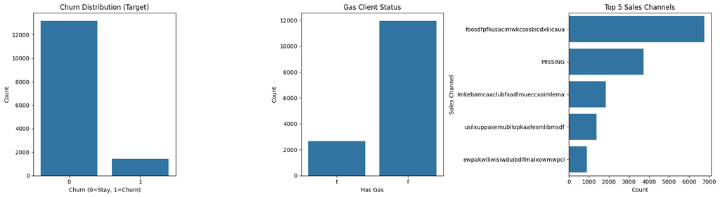

```python
# Data Visualization: Target and Key Categorical Features
plt.figure(figsize=(18, 5))

# Plot 1: Churn Distribution (Target Variable)
plt.subplot(1, 3, 1)
sns.countplot(x='churn', data=df_client)
plt.title('Churn Distribution (Target)')
plt.xlabel('Churn (0=Stay, 1=Churn)')
plt.ylabel('Count')

# Plot 2: Has Gas (Binary Feature) # has_gas col in client_data.csv indicated if client is also a gas client, its a key piece of information for segmenting the customers.
# Since it's a binary indicator, it tells you for each client:
# Yes, this client is a gas customer. (Dual-fuel customer)
# No, this client is only an electricity customer.
plt.subplot(1, 3, 2)
sns.countplot(x='has_gas', data=df_client)
plt.title('Gas Client Status')
plt.xlabel('Has Gas')
plt.ylabel('Count')


# Plot 3: Top Sales Channels (Categorical Feature)
plt.subplot(1, 3, 3)
# Find the top 5 channels to keep the plot clean
top_channels = df_client['channel_sales'].value_counts().nlargest(5).index
sns.countplot(y='channel_sales', data=df_client, order=top_channels)
plt.title('Top 5 Sales Channels')
plt.xlabel('Count')
plt.ylabel('Sales Channel')

plt.tight_layout()
plt.show()
```

```python
# Calculate and print the churn rate for the 'MISSING' sales channel group.
missing_churn_rate = df_client[df_client['channel_sales'] == 'MISSING']['churn'].mean() * 100
overall_churn_rate = df_client['churn'].mean() * 100

print(f"\n✅ Validation: Overall Churn Rate: {overall_churn_rate:.2f}%")
print(f"✅ Validation: Churn Rate for 'MISSING' Sales Channel: {missing_churn_rate:.2f}%")
```

```
✅ Validation: Overall Churn Rate: 9.72%
✅ Validation: Churn Rate for 'MISSING' Sales Channel: 7.60%
```

This block of code performs the Numeric Data Visualization.

It creates four distribution charts (histograms) to clearly show the range and most common values for the main numerical features, especially consumption and revenue.

```
Numeric Features: Log Distribution (Checking for Skewness/Outliers)
```

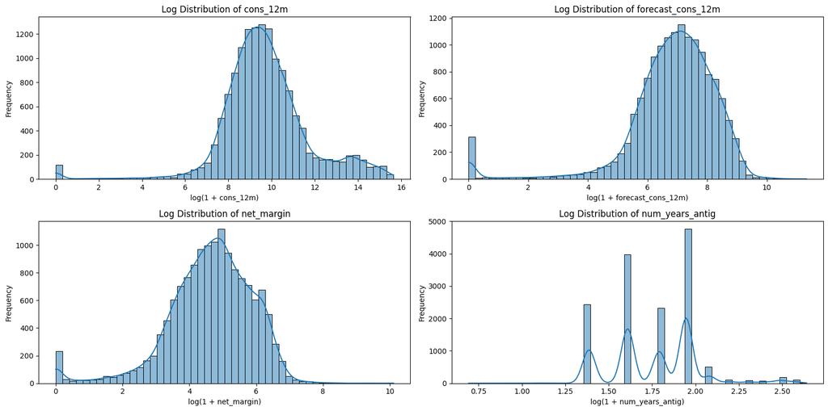

```python
# Numeric Features (Log Distribution for Skewness)
# Use a log transformation to visually inspect the distributions of the skewed consumption and financial data.
print("\nNumeric Features: Log Distribution (Checking for Skewness/Outliers)")
# Key numerical columns prone to high skewness
numeric_cols_to_plot = ['cons_12m', 'forecast_cons_12m', 'net_margin', 'num_years_antig']

plt.figure(figsize=(16, 8))

for i, col in enumerate(numeric_cols_to_plot):
    plt.subplot(2, 2, i + 1)
    # Apply np.log1p(x) (log(1+x)) for robust visualization as it handles zeros
    sns.histplot(df_client[col].apply(lambda x: np.log1p(x)).dropna(), kde=True, bins=50)
    plt.title(f'Log Distribution of {col}')
    plt.xlabel(f'log(1 + {col})')
    plt.ylabel('Frequency')

plt.tight_layout()
plt.show()
print("-" * 70)
```

This block of code performs the Price Data Visualization.

It creates three distribution charts (histograms) to show the variety and commonality of the prices customers were charged historically.

```
Price Features Distribution
```

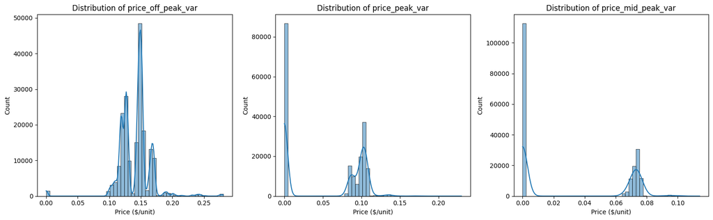

```python
# Price Features Distribution
print("\nPrice Features Distribution")
# Focus on the variable price components
price_cols_to_plot = ['price_off_peak_var', 'price_peak_var', 'price_mid_peak_var']

plt.figure(figsize=(16, 5))

for i, col in enumerate(price_cols_to_plot):
    plt.subplot(1, 3, i + 1)
    sns.histplot(df_price[col].dropna(), kde=True, bins=50)
    plt.title(f'Distribution of {col}')
    plt.xlabel('Price ($/unit)')
    plt.ylabel('Count')

plt.tight_layout()
plt.show()
print("-" * 70)
```